# **Regression Project: Boston House Price Prediction**

## **Objective**

The problem at hand is to **predict the housing prices of a town or a suburb based on the features of the locality provided to us**. In the process, we need to **identify the most important features affecting the price of the house**. We need to employ techniques of data preprocessing and build a linear regression model that predicts the prices for the unseen data.

## **Dataset**

Each record in the database describes a house in Boston suburb or town. The data was drawn from the Boston Standard Metropolitan Statistical Area (SMSA) in 1970. Detailed attribute information can be found below:

Attribute Information:

- **CRIM:** Per capita crime rate by town
- **ZN:** Proportion of residential land zoned for lots over 25,000 sq.ft.
- **INDUS:** Proportion of non-retail business acres per town
- **CHAS:** Charles River dummy variable (= 1 if tract bounds river; 0 otherwise)
- **NOX:** Nitric Oxide concentration (parts per 10 million)
- **RM:** The average number of rooms per dwelling
- **AGE:** Proportion of owner-occupied units built before 1940
- **DIS:** Weighted distances to five Boston employment centers
- **RAD:** Index of accessibility to radial highways
- **TAX:** Full-value property-tax rate per 10,000 dollars
- **PTRATIO:** Pupil-teacher ratio by town
- **LSTAT:** % lower status of the population
- **MEDV:** Median value of owner-occupied homes in 1000 dollars

## **Importing the necessary libraries**

```python
import pandas as pd
import numpy as np
import matplotlib.pyplot as plt
import seaborn as sns
import math
from statsmodels.graphics.gofplots import ProbPlot
from statsmodels.formula.api import ols
import statsmodels.api as sm
from statsmodels.stats.outliers_influence import variance_inflation_factor
from sklearn.linear_model import LinearRegression
from sklearn.model_selection import train_test_split
from sklearn.metrics import mean_squared_error, r2_score, mean_absolute_error,mean_absolute_percentage_error
from sklearn.model_selection import cross_val_score
from statsmodels.stats.diagnostic import het_white
from statsmodels.compat import lzip
import statsmodels.stats.api as sms
from google.colab import drive
```

### Loading the dataset

```python
drive.mount('/content/drive/')
df1 = pd.read_csv('/content/drive/MyDrive/GL/datasets/Boston.csv')
df = df1.copy()
```

## Data Overview

```python
df.head()
```

|  | CRIM | ZN | INDUS | CHAS | NOX | RM | AGE | DIS | RAD | TAX | PTRATIO | LSTAT | MEDV |
| --- | --- | --- | --- | --- | --- | --- | --- | --- | --- | --- | --- | --- | --- |
| 0 | 0.00632 | 18.0 | 2.31 | 0 | 0.538 | 6.575 | 65.2 | 4.0900 | 1 | 296 | 15.3 | 4.98 | 24.0 |
| 1 | 0.02731 | 0.0 | 7.07 | 0 | 0.469 | 6.421 | 78.9 | 4.9671 | 2 | 242 | 17.8 | 9.14 | 21.6 |
| 2 | 0.02729 | 0.0 | 7.07 | 0 | 0.469 | 7.185 | 61.1 | 4.9671 | 2 | 242 | 17.8 | 4.03 | 34.7 |
| 3 | 0.03237 | 0.0 | 2.18 | 0 | 0.458 | 6.998 | 45.8 | 6.0622 | 3 | 222 | 18.7 | 2.94 | 33.4 |
| 4 | 0.06905 | 0.0 | 2.18 | 0 | 0.458 | 7.147 | 54.2 | 6.0622 | 3 | 222 | 18.7 | 5.33 | 36.2 |

```python
df.info()
```

```
<class 'pandas.core.frame.DataFrame'>
RangeIndex: 506 entries, 0 to 505
Data columns (total 13 columns):
 #   Column   Non-Null Count  Dtype
---  ------   --------------  -----
 0   CRIM     506 non-null    float64
 1   ZN       506 non-null    float64
 2   INDUS    506 non-null    float64
 3   CHAS     506 non-null    int64
 4   NOX      506 non-null    float64
 5   RM       506 non-null    float64
 6   AGE      506 non-null    float64
 7   DIS      506 non-null    float64
 8   RAD      506 non-null    int64
 9   TAX      506 non-null    int64
 10  PTRATIO  506 non-null    float64
 11  LSTAT    506 non-null    float64
 12  MEDV     506 non-null    float64
dtypes: float64(10), int64(3)
memory usage: 51.5 KB
```

```python
df.shape
```

```
(506, 13)
```

```python
df.duplicated().any()
```

```
False
```

No duplicated values

```python
df.isnull().sum().sum()
```

```
0
```

No null values

```python
df.describe().T
```

|  | count | mean | std | min | 25% | 50% | 75% | max |
| --- | --- | --- | --- | --- | --- | --- | --- | --- |
| CRIM | 506.0 | 3.613524 | 8.601545 | 0.00632 | 0.082045 | 0.25651 | 3.677083 | 88.9762 |
| ZN | 506.0 | 11.363636 | 23.322453 | 0.00000 | 0.000000 | 0.00000 | 12.500000 | 100.0000 |
| INDUS | 506.0 | 11.136779 | 6.860353 | 0.46000 | 5.190000 | 9.69000 | 18.100000 | 27.7400 |
| CHAS | 506.0 | 0.069170 | 0.253994 | 0.00000 | 0.000000 | 0.00000 | 0.000000 | 1.0000 |
| NOX | 506.0 | 0.554695 | 0.115878 | 0.38500 | 0.449000 | 0.53800 | 0.624000 | 0.8710 |
| RM | 506.0 | 6.284634 | 0.702617 | 3.56100 | 5.885500 | 6.20850 | 6.623500 | 8.7800 |
| AGE | 506.0 | 68.574901 | 28.148861 | 2.90000 | 45.025000 | 77.50000 | 94.075000 | 100.0000 |
| DIS | 506.0 | 3.795043 | 2.105710 | 1.12960 | 2.100175 | 3.20745 | 5.188425 | 12.1265 |
| RAD | 506.0 | 9.549407 | 8.707259 | 1.00000 | 4.000000 | 5.00000 | 24.000000 | 24.0000 |
| TAX | 506.0 | 408.237154 | 168.537116 | 187.00000 | 279.000000 | 330.00000 | 666.000000 | 711.0000 |
| PTRATIO | 506.0 | 18.455534 | 2.164946 | 12.60000 | 17.400000 | 19.05000 | 20.200000 | 22.0000 |
| LSTAT | 506.0 | 12.653063 | 7.141062 | 1.73000 | 6.950000 | 11.36000 | 16.955000 | 37.9700 |
| MEDV | 506.0 | 22.532806 | 9.197104 | 5.00000 | 17.025000 | 21.20000 | 25.000000 | 50.0000 |

Above we can see a statistical summary of the data.

## Exploratory Data Analysis (EDA)

- EDA is an important part of any project involving data.
- It is important to investigate and understand the data better before building a model with it.
- A few questions have been mentioned below which will help you approach the analysis in the right manner and generate insights from the data.
- A thorough analysis of the data, in addition to the questions mentioned below, should be done.

```python
def histogram_boxplot(data, feature, figsize=(8,1.5), kde=True,color=None):
    fig, (ax_box, ax_hist) = plt.subplots(2, sharex=True, gridspec_kw={"height_ratios": [0.25, 0.75]}, figsize=figsize)

    sns.histplot(data=data, x=feature, kde=kde, ax=ax_hist,color=color)
    sns.boxplot(data=data, x=feature, ax=ax_box, showmeans=True,color=color)

    # Remove the boxplot x labels
    ax_box.set_xlabel('')

    #removing space between plots
    plt.subplots_adjust(hspace=0)
```

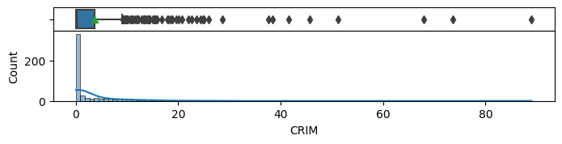

```python
histogram_boxplot(df, 'CRIM')
```

CRIM is heavily right skewed with outliers past 80.

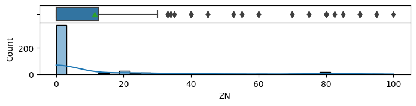

```python
histogram_boxplot(df, 'ZN')
```

ZN is also right skewed with outliers from around to 100

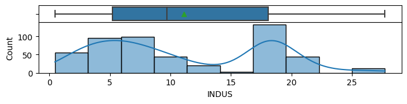

```python
histogram_boxplot(df, 'INDUS')
```

INDUS appears bimodal with peaks around 17 and 6.

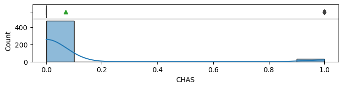

```python
histogram_boxplot(df, 'CHAS')
```

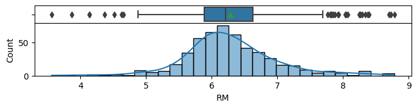

```python
histogram_boxplot(df, 'RM')
```

RM is evenly distributed with a mean right above 6 and with beyond each whisker.

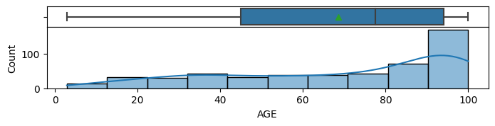

```python
histogram_boxplot(df, 'AGE')
```

Age is left skewed with an average right below 70.

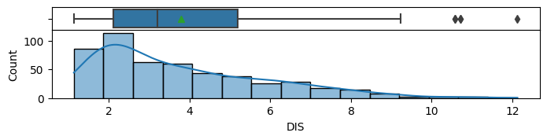

```python
histogram_boxplot(df, 'DIS')
```

DIS is right skewed with an average right below 4.

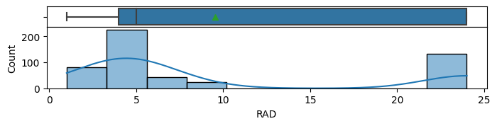

```python
histogram_boxplot(df, 'RAD')
```

RAD appears to be bimodal, with a larger peak at 5 and another around 22.

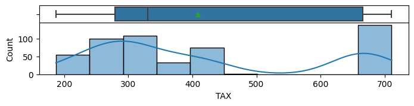

```python
histogram_boxplot(df, 'TAX')
```

TAX is also bimodal with a similar distribution as RAD.

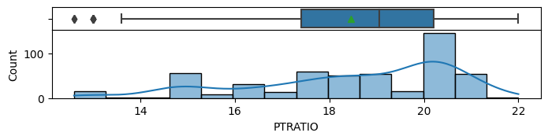

```python
histogram_boxplot(df, 'PTRATIO')
```

PTRATIO is left skewed with an average at around 18.

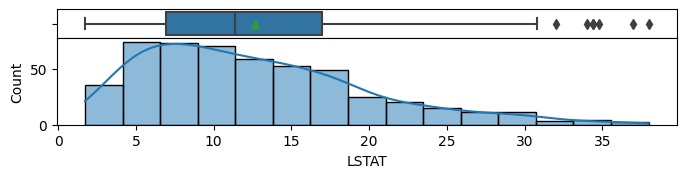

```python
histogram_boxplot(df, 'LSTAT')
```

LSTAT is right skewed with an average around 12.

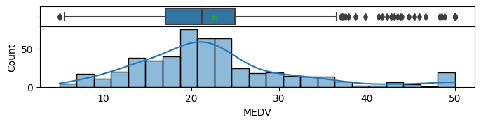

```python
histogram_boxplot(df, 'MEDV')
```

MEDV is slightly right skewed with outliers on the right and a small increase around 50.

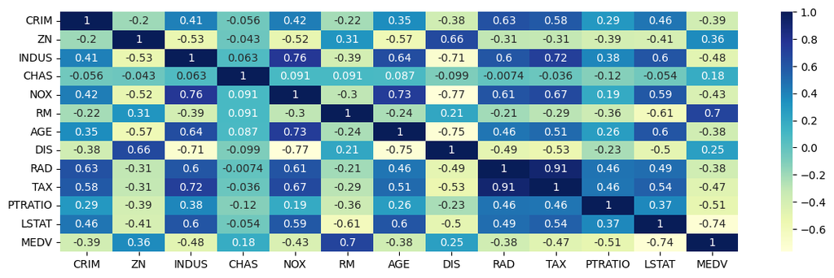

```python
#creating heatmap
plt.subplots(figsize=(14,4))
sns.heatmap(df.corr(),cmap="YlGnBu",annot=True);
```

We can see positive & negative correlation exists between MEDV & features as well as between the features themselves.

- AGE & DIS = -.75 Houses are older the closer to the employment centers.
- AGE & NOX = .73 Nitrous Oxide is higher in older areas.
- DIS & INDUS = -.71 Distance from epmloyment centers goes down as proportion of non-retail businesses increase.
- DIS & NOX = -.77 Nitrous oxide goes the further from employment centers.
- INDUS & NOX = .76 Nitrous Oxide increases with proportion of non-retail businesses.
- INDUS & TAX = .72 Tax rate increases with proportion of non-retail businesses.
- RAD & TAX = .91 - Tax rates increase with more radial access to highways.
- MEDV & LSTAT = -.74 MEDV goes down as there is a higher % of low status population.
- MEDV & RM = .7 : MEDV increases as rooms increase.

High correlations between RAD and TAX may be an issue of mult-collinearity.

```python
#function that creates scatterplots for high and low corrs
def high_corr_scatterplots2(df, high=0.7, low=-0.7):

  corr_matrix = df.corr().round(2)
  #getting column and row names where they arent the same and if they are between high and low corrs
  high_corr_pairs = [(feat1, feat2) for feat1 in df.columns for feat2 in df.columns
                      if feat1 != feat2 and (corr_matrix.loc[feat1, feat2] >= high or corr_matrix.loc[feat1, feat2] <= low)]

  #creating a set to drop pair duplicates then plotting scatterplot for each pair.
  unique_pairs = set(tuple(sorted(pair)) for pair in high_corr_pairs)
  for feature1, feature2 in unique_pairs:
      plt.figure(figsize=(5,5))
      sns.scatterplot(data=df, x=feature1, y=feature2, color='blue');
      plt.title(f'{feature1} and {feature2}');
      plt.show()
```

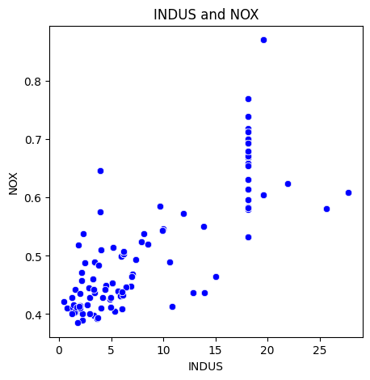

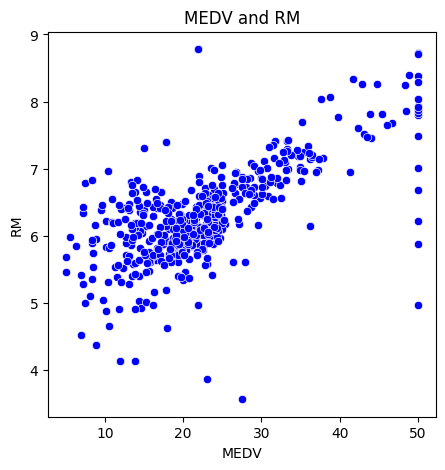

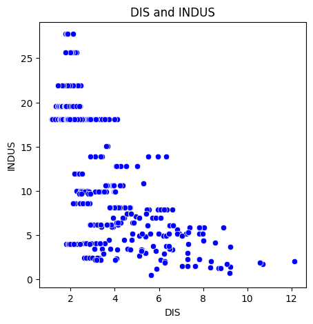

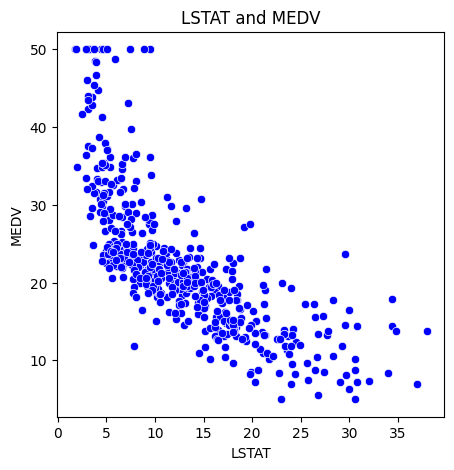

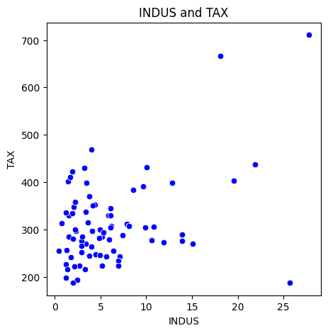

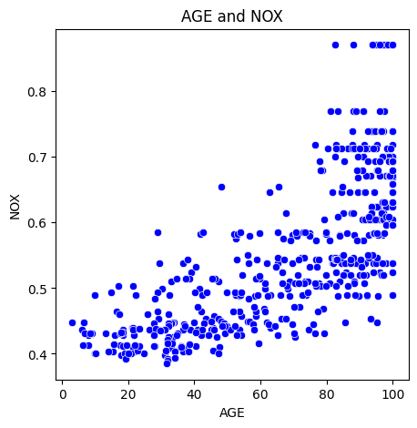

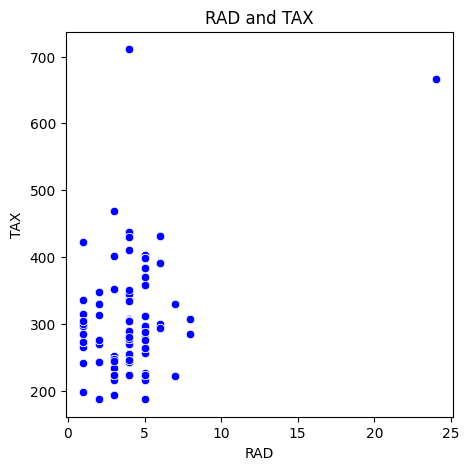

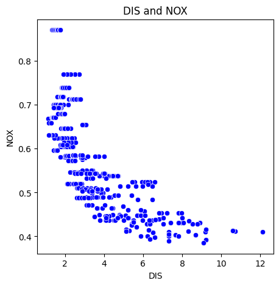

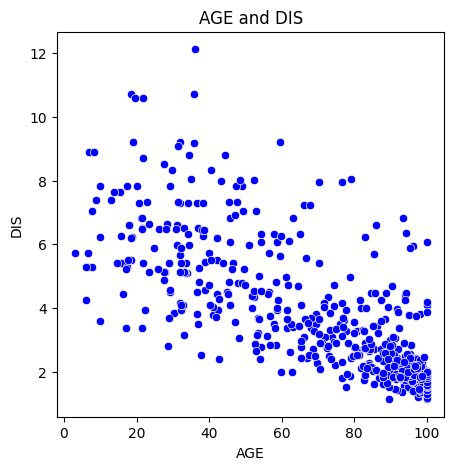

```python
high_corr_scatterplots2(df,high = .7,low = -.7)
```

As we can see in the graph, most plots seem closely grouped, but we can see some distant outliers in RAD and TAX & INDUS and TAX that may be skewing correlation and/or leading to multi-collinearity.

It also appears that several features are capped at a ceiling, such as MEDV at 50

```python
#creating df of top right point in TAX and RAD chart then viewing lenght
taxrad = df[(df['RAD']> 22)&(df['TAX']> 650)]
len(taxrad)
```

```
132
```

```python
taxrad.describe().T
```

|  | count | mean | std | min | 25% | 50% | 75% | max |
| --- | --- | --- | --- | --- | --- | --- | --- | --- |
| CRIM | 132.0 | 12.759291 | 1.304117e+01 | 2.37857 | 5.686307 | 9.08499 | 14.3337 | 88.9762 |
| ZN | 132.0 | 0.000000 | 0.000000e+00 | 0.00000 | 0.000000 | 0.00000 | 0.0000 | 0.0000 |
| INDUS | 132.0 | 18.100000 | 7.132496e-15 | 18.10000 | 18.100000 | 18.10000 | 18.1000 | 18.1000 |
| CHAS | 132.0 | 0.060606 | 2.395153e-01 | 0.00000 | 0.000000 | 0.00000 | 0.0000 | 1.0000 |
| NOX | 132.0 | 0.672417 | 6.100432e-02 | 0.53200 | 0.614000 | 0.69300 | 0.7130 | 0.7700 |
| RM | 132.0 | 6.022152 | 7.184487e-01 | 3.56100 | 5.713000 | 6.17600 | 6.4190 | 8.7800 |
| AGE | 132.0 | 89.805303 | 1.262581e+01 | 40.30000 | 85.925000 | 94.40000 | 98.8250 | 100.0000 |
| DIS | 132.0 | 2.061254 | 6.179013e-01 | 1.12960 | 1.589250 | 1.94340 | 2.4313 | 4.0983 |
| RAD | 132.0 | 24.000000 | 0.000000e+00 | 24.00000 | 24.000000 | 24.00000 | 24.0000 | 24.0000 |
| TAX | 132.0 | 666.000000 | 0.000000e+00 | 666.00000 | 666.000000 | 666.00000 | 666.0000 | 666.0000 |
| PTRATIO | 132.0 | 20.200000 | 0.000000e+00 | 20.20000 | 20.200000 | 20.20000 | 20.2000 | 20.2000 |
| LSTAT | 132.0 | 18.600606 | 6.905296e+00 | 2.96000 | 14.175000 | 17.91000 | 23.0450 | 37.9700 |
| MEDV | 132.0 | 16.403788 | 8.539745e+00 | 5.00000 | 11.225000 | 14.40000 | 19.9000 | 50.0000 |

We can see there are 132 properties with RAD at 24 and TAX at 666. It appears these 132 properties also share similar values in other fields as well.

Lets check the lenght of the other outlier from the RAD and TAX scatterplot

```python
len(df[(df['RAD']< 6)&(df['TAX']> 700)])
```

```
5
```

There are only 5 properties that share that point.

```python
df[(df['RAD']< 6)&(df['TAX']> 700)]
```

|  | CRIM | ZN | INDUS | CHAS | NOX | RM | AGE | DIS | RAD | TAX | PTRATIO | LSTAT | MEDV |
| --- | --- | --- | --- | --- | --- | --- | --- | --- | --- | --- | --- | --- | --- |
| 488 | 0.15086 | 0.0 | 27.74 | 0 | 0.609 | 5.454 | 92.7 | 1.8209 | 4 | 711 | 20.1 | 18.06 | 15.2 |
| 489 | 0.18337 | 0.0 | 27.74 | 0 | 0.609 | 5.414 | 98.3 | 1.7554 | 4 | 711 | 20.1 | 23.97 | 7.0 |
| 490 | 0.20746 | 0.0 | 27.74 | 0 | 0.609 | 5.093 | 98.0 | 1.8226 | 4 | 711 | 20.1 | 29.68 | 8.1 |
| 491 | 0.10574 | 0.0 | 27.74 | 0 | 0.609 | 5.983 | 98.8 | 1.8681 | 4 | 711 | 20.1 | 18.07 | 13.6 |
| 492 | 0.11132 | 0.0 | 27.74 | 0 | 0.609 | 5.983 | 83.5 | 2.1099 | 4 | 711 | 20.1 | 13.35 | 20.1 |

Let's also look into MEDV and RM as there are outliers that may throw off a linear model. Because RM is one of the higher correlated fields to our target, MEDV, we will attempt to visually 'winsorize' the extreme points by moving them closer to the next highest points so they will not throw off the model completely and we still will retain noise.

## Data Preprocessing

Looking at our label, MEDV, we can see that there are several points that may be of concern for a linear model. We will attempt to visually winsorize the points by bringing them closer to the next extreme value near them. That way we can keep noise as well as not throw off our model.

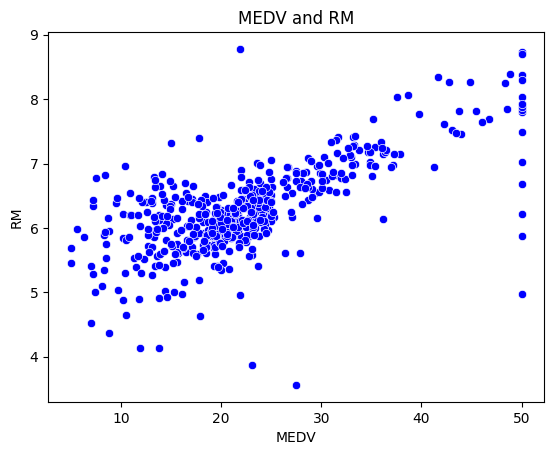

```python
sns.scatterplot(data=df, x="MEDV", y='RM', color='blue')
plt.title(f'MEDV and RM');
```

```python
# finding the points, then assigning them a new value
```

```python
df[(df['MEDV']==50 )&(df['RM']<5)]
```

|  | CRIM | ZN | INDUS | CHAS | NOX | RM | AGE | DIS | RAD | TAX | PTRATIO | LSTAT | MEDV |
| --- | --- | --- | --- | --- | --- | --- | --- | --- | --- | --- | --- | --- | --- |
| 368 | 4.89822 | 0.0 | 18.1 | 0 | 0.631 | 4.97 | 100.0 | 1.3325 | 24 | 666 | 20.2 | 3.26 | 50.0 |

```python
condition = (df['MEDV']==50 )&(df['RM']<5)
df.loc[condition,'MEDV'] = 21
```

```python
df[(df['MEDV']==50 )&(df['RM']<6.5)]
```

|  | CRIM | ZN | INDUS | CHAS | NOX | RM | AGE | DIS | RAD | TAX | PTRATIO | LSTAT | MEDV |
| --- | --- | --- | --- | --- | --- | --- | --- | --- | --- | --- | --- | --- | --- |
| 371 | 9.23230 | 0.0 | 18.1 | 0 | 0.631 | 6.216 | 100.0 | 1.1691 | 24 | 666 | 20.2 | 9.53 | 50.0 |
| 372 | 8.26725 | 0.0 | 18.1 | 1 | 0.668 | 5.875 | 89.6 | 1.1296 | 24 | 666 | 20.2 | 8.88 | 50.0 |

```python
condition = (df['MEDV']==50 )&(df['RM']<6.5)
df.loc[condition,'MEDV'] = 40
```

```python
df[(df['MEDV']==50 )&(df['RM']<7.2)]
```

|  | CRIM | ZN | INDUS | CHAS | NOX | RM | AGE | DIS | RAD | TAX | PTRATIO | LSTAT | MEDV |
| --- | --- | --- | --- | --- | --- | --- | --- | --- | --- | --- | --- | --- | --- |
| 369 | 5.66998 | 0.0 | 18.1 | 1 | 0.631 | 6.683 | 96.8 | 1.3567 | 24 | 666 | 20.2 | 3.73 | 50.0 |
| 370 | 6.53876 | 0.0 | 18.1 | 1 | 0.631 | 7.016 | 97.5 | 1.2024 | 24 | 666 | 20.2 | 2.96 | 50.0 |

```python
condition = (df['MEDV']==50 )&(df['RM']<7.2)
df.loc[condition,'MEDV'] = 46
```

```python
df[(df['MEDV']>20 )&(df['RM']<4.5)]
```

|  | CRIM | ZN | INDUS | CHAS | NOX | RM | AGE | DIS | RAD | TAX | PTRATIO | LSTAT | MEDV |
| --- | --- | --- | --- | --- | --- | --- | --- | --- | --- | --- | --- | --- | --- |
| 365 | 4.55587 | 0.0 | 18.1 | 0 | 0.718 | 3.561 | 87.9 | 1.6132 | 24 | 666 | 20.2 | 7.12 | 27.5 |
| 367 | 13.52220 | 0.0 | 18.1 | 0 | 0.631 | 3.863 | 100.0 | 1.5106 | 24 | 666 | 20.2 | 13.33 | 23.1 |

```python
condition = (df['MEDV']>20 )&(df['RM']<4.5)
df.loc[condition,'MEDV'] = 15
```

```python
df[(df['MEDV']<30 )&(df['RM']>8)]
```

|  | CRIM | ZN | INDUS | CHAS | NOX | RM | AGE | DIS | RAD | TAX | PTRATIO | LSTAT | MEDV |
| --- | --- | --- | --- | --- | --- | --- | --- | --- | --- | --- | --- | --- | --- |
| 364 | 3.47428 | 0.0 | 18.1 | 1 | 0.718 | 8.78 | 82.9 | 1.9047 | 24 | 666 | 20.2 | 5.29 | 21.9 |

```python
condition = (df['MEDV']<30 )&(df['RM']>8)
df.loc[condition,'MEDV'] = 35
```

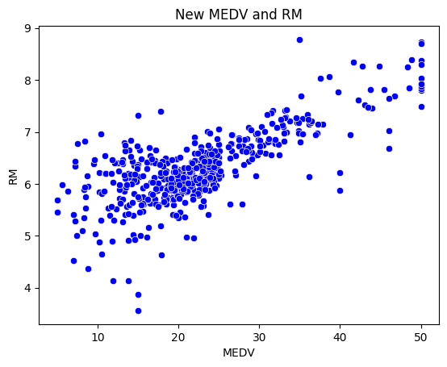

```python
sns.scatterplot(data=df, x="MEDV", y='RM', color='blue')
plt.title(f'New MEDV and RM');
```

We saw earlier that MEDV was slighlty skewed, so we we will log transform it.

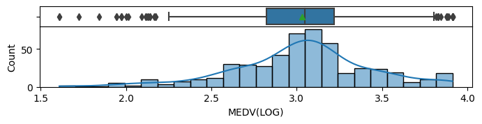

```python
df['MEDV(LOG)'] = np.log(df['MEDV'])
histogram_boxplot(df, 'MEDV(LOG)')
```

### Multicollinearity check

```python
#seperating label and dropping from X df
y = df['MEDV(LOG)']

X = df.drop(['MEDV','MEDV(LOG)'],axis=1)
X = sm.add_constant(X)
```

```python
#splitting
X_train, X_test, y_train, y_test = train_test_split(X, y, test_size=0.3, random_state=1)
```

```python
#function for vif
def vif(xtrain):
    vifdf = pd.DataFrame()
    vifdf["feature"] = xtrain.columns
    # finding vif for each column
    vifdf["VIF"] = [variance_inflation_factor(xtrain.values, i) for i in range(xtrain.shape[1])]
    return vifdf

vif(X_train)
```

|  | feature | VIF |
| --- | --- | --- |
| 0 | const | 535.372593 |
| 1 | CRIM | 1.924114 |
| 2 | ZN | 2.743574 |
| 3 | INDUS | 3.999538 |
| 4 | CHAS | 1.076564 |
| 5 | NOX | 4.396157 |
| 6 | RM | 1.860950 |
| 7 | AGE | 3.150170 |
| 8 | DIS | 4.355469 |
| 9 | RAD | 8.345247 |
| 10 | TAX | 10.191941 |
| 11 | PTRATIO | 1.943409 |
| 12 | LSTAT | 2.861881 |

As we can see the RAD and TAX have VIF over 5. There isn't a practical way to combine these into an easily interpretable column, so we will drop Tax.

```python
df = df.drop('TAX',axis=1)

y = df['MEDV(LOG)']
X = df.drop(['MEDV','MEDV(LOG)'],axis=1)
X = sm.add_constant(X)

X_train, X_test, y_train, y_test = train_test_split(X, y, test_size=0.3, random_state=1)
```

```python
vif(X_train)
```

|  | feature | VIF |
| --- | --- | --- |
| 0 | const | 532.025529 |
| 1 | CRIM | 1.923159 |
| 2 | ZN | 2.483399 |
| 3 | INDUS | 3.270983 |
| 4 | CHAS | 1.050708 |
| 5 | NOX | 4.361847 |
| 6 | RM | 1.857918 |
| 7 | AGE | 3.149005 |
| 8 | DIS | 4.333734 |
| 9 | RAD | 2.942862 |
| 10 | PTRATIO | 1.909750 |
| 11 | LSTAT | 2.860251 |

We can see that VIF for RAD is now fixed.

## Model Building - Linear Regression

```python
# creating model, fitting training data
ols_model = sm.OLS(y_train, X_train).fit()

# summary
ols_model.summary()
```

OLS Regression Results

| Dep. Variable: | MEDV(LOG) | R-squared: | 0.793 |
| --- | --- | --- | --- |
| Model: | OLS | Adj. R-squared: | 0.787 |
| Method: | Least Squares | F-statistic: | 119.4 |
| Date: | Thu, 28 Sep 2023 | Prob (F-statistic): | 6.13e-110 |
| Time: | 22:22:16 | Log-Likelihood: | 100.48 |
| No. Observations: | 354 | AIC: | -177.0 |
| Df Residuals: | 342 | BIC: | -130.5 |
| Df Model: | 11 |  |  |
| Covariance Type: | nonrobust |  |  |

|  | coef | std err | t | P>\|t\| | [0.025 | 0.975] |
| --- | --- | --- | --- | --- | --- | --- |
| const | 4.0634 | 0.227 | 17.883 | 0.000 | 3.616 | 4.510 |
| CRIM | -0.0121 | 0.002 | -7.561 | 0.000 | -0.015 | -0.009 |
| ZN | 0.0005 | 0.001 | 0.715 | 0.475 | -0.001 | 0.002 |
| INDUS | -0.0002 | 0.003 | -0.094 | 0.925 | -0.005 | 0.005 |
| CHAS | 0.1298 | 0.036 | 3.579 | 0.000 | 0.058 | 0.201 |
| NOX | -0.9366 | 0.175 | -5.365 | 0.000 | -1.280 | -0.593 |
| RM | 0.1200 | 0.019 | 6.181 | 0.000 | 0.082 | 0.158 |
| AGE | -0.0005 | 0.001 | -0.808 | 0.420 | -0.002 | 0.001 |
| DIS | -0.0442 | 0.010 | -4.597 | 0.000 | -0.063 | -0.025 |
| RAD | 0.0048 | 0.002 | 2.503 | 0.013 | 0.001 | 0.009 |
| PTRATIO | -0.0422 | 0.006 | -6.645 | 0.000 | -0.055 | -0.030 |
| LSTAT | -0.0235 | 0.002 | -10.250 | 0.000 | -0.028 | -0.019 |

| Omnibus: | 27.190 | Durbin-Watson: | 1.932 |
| --- | --- | --- | --- |
| Prob(Omnibus): | 0.000 | Jarque-Bera (JB): | 102.799 |
| Skew: | 0.108 | Prob(JB): | 4.76e-23 |
| Kurtosis: | 5.631 | Cond. No. | 2.09e+03 |

Notes:  
[1] Standard Errors assume that the covariance matrix of the errors is correctly specified.  
[2] The condition number is large, 2.09e+03. This might indicate that there are  
strong multicollinearity or other numerical problems.

We can see right away that ZN, INDUS, & AGE have low coefficients(nearing zero). Meaning these features are essentially useless to our model. Lets drop these.

```python
y = df['MEDV(LOG)']
X = df.drop(['MEDV','MEDV(LOG)','ZN','INDUS','AGE'],axis=1)
X = sm.add_constant(X)

X_train, X_test, y_train, y_test = train_test_split(X, y, test_size=0.3, random_state=1)

# creating model, fitting training data
ols_model = sm.OLS(y_train, X_train).fit()

# summary
ols_model.summary()
```

OLS Regression Results

| Dep. Variable: | MEDV(LOG) | R-squared: | 0.793 |
| --- | --- | --- | --- |
| Model: | OLS | Adj. R-squared: | 0.788 |
| Method: | Least Squares | F-statistic: | 164.8 |
| Date: | Thu, 28 Sep 2023 | Prob (F-statistic): | 6.04e-113 |
| Time: | 22:22:17 | Log-Likelihood: | 99.805 |
| No. Observations: | 354 | AIC: | -181.6 |
| Df Residuals: | 345 | BIC: | -146.8 |
| Df Model: | 8 |  |  |
| Covariance Type: | nonrobust |  |  |

|  | coef | std err | t | P>\|t\| | [0.025 | 0.975] |
| --- | --- | --- | --- | --- | --- | --- |
| const | 4.0841 | 0.226 | 18.105 | 0.000 | 3.640 | 4.528 |
| CRIM | -0.0120 | 0.002 | -7.540 | 0.000 | -0.015 | -0.009 |
| CHAS | 0.1287 | 0.036 | 3.559 | 0.000 | 0.058 | 0.200 |
| NOX | -0.9808 | 0.157 | -6.262 | 0.000 | -1.289 | -0.673 |
| RM | 0.1192 | 0.019 | 6.343 | 0.000 | 0.082 | 0.156 |
| DIS | -0.0377 | 0.007 | -5.094 | 0.000 | -0.052 | -0.023 |
| RAD | 0.0051 | 0.002 | 2.720 | 0.007 | 0.001 | 0.009 |
| PTRATIO | -0.0445 | 0.006 | -7.696 | 0.000 | -0.056 | -0.033 |
| LSTAT | -0.0242 | 0.002 | -11.444 | 0.000 | -0.028 | -0.020 |

| Omnibus: | 26.801 | Durbin-Watson: | 1.931 |
| --- | --- | --- | --- |
| Prob(Omnibus): | 0.000 | Jarque-Bera (JB): | 98.785 |
| Skew: | 0.119 | Prob(JB): | 3.54e-22 |
| Kurtosis: | 5.577 | Cond. No. | 690. |

Notes:  
[1] Standard Errors assume that the covariance matrix of the errors is correctly specified.

## Checking Linear Regression Assumptions

#### **Heteroscedasticity test**

The GoldfeldQuandt test is a common way to test for Heteroscedasticity.

```python
#performing goldfeldquandt test for heteroscedasticity
gq = sms.het_goldfeldquandt(y_train, X_train)

# Access the test statistics and p-value
p_value = gq[1]

print(f"P-value: {np.round(p_value,4)}")
```

```
P-value: 0.4853
```

#### **Residual Mean + Normality**

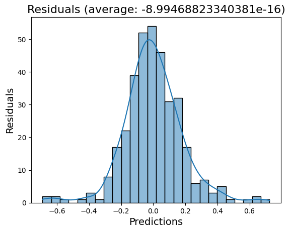

```python
#defining residuals
residuals = ols_model.resid

#creating plot
ax = sns.histplot(residuals,kde=True);
ax.set_xlabel("Predictions", fontsize=14)
ax.set_ylabel("Residuals", fontsize=14)
ax.set_title(f'Residuals (average: {np.mean(residuals)})',fontsize=16);
```

#### **Linearity**

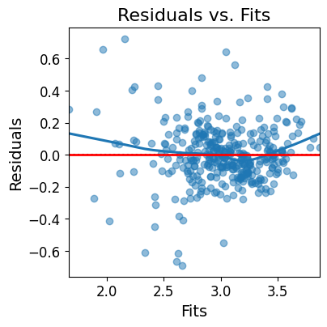

```python
plt.figure(figsize=(4, 4))
ax = sns.residplot(x=ols_model.fittedvalues, y=residuals, lowess=True, scatter_kws={'alpha': 0.5})

# Customize the plot
ax.set_xlabel("Fits", fontsize=14)
ax.set_ylabel("Residuals", fontsize=14)
ax.set_title("Residuals vs. Fits", fontsize=16)
ax.axhline(y=0, color='r', linewidth=2)  # Add a horizontal line at y=0 for reference

# Adjust the tick label font size
ax.tick_params(axis='both', labelsize=12)

# Show the plot
plt.show()
```

We can see that there isn't a clear shape or pattern suggesting that fit values and residuals are linearly correlated.

### Metrics

```python
print("r^2:", np.round(ols_model.rsquared,5))
```

```
r^2: 0.79264
```

Training set results

```python
actual = y_train
predicted = ols_model.predict(X_train)

mae = np.mean(np.abs(actual - predicted))
rmse = np.sqrt(((actual - predicted) ** 2).mean())
mape = np.mean(np.abs((actual - predicted)) / actual) * 100

print("MAE:", np.round(mae,5))
print("RMSE:", np.round(rmse,5))
print("MAPE:", np.round(mape,5))
```

```
MAE: 0.13233
RMSE: 0.18252
MAPE: 4.66828
```

Test set results

```python
actual = y_test
predicted = ols_model.predict(X_test)

mae = np.mean(np.abs(actual - predicted))
rmse = np.sqrt(((actual - predicted) ** 2).mean())
mape = np.mean(np.abs((actual - predicted)) / actual) * 100

print("MAE:", np.round(mae,5))
print("RMSE:", np.round(rmse,5))
print("MAPE:", np.round(mape,5))
```

```
MAE: 0.14199
RMSE: 0.18836
MAPE: 4.98153
```

Comparing Test and Training we see that error metrics values are slightly higher on the Test set.

### Cross Validation

```python
from scipy.stats import fit
#creating model
linear_model = LinearRegression()

y = df['MEDV(LOG)']
X = df.drop(['MEDV','MEDV(LOG)','ZN','INDUS','AGE'],axis=1)

X_train, X_test, y_train, y_test = train_test_split(X, y, test_size=0.3, random_state=42)

scores = np.array(np.round(np.sqrt(abs(cross_val_score(linear_model, X_train, y_train, scoring = 'neg_mean_squared_error',cv=10))),5))
scores = scores.reshape(5,2)

print('    ---Scores---')
print(scores)
print('------------')
print(f'Mean: {scores.mean()}')
```

```
    ---Scores---
[[0.2032  0.19011]
 [0.1412  0.24312]
 [0.21257 0.20796]
 [0.17093 0.19795]
 [0.12296 0.23218]]
------------
Mean: 0.192218
```

As expected we can see CV has given the model a range of scores sometimes performing much better than others. The average is 0.192218.

## Final Model

```python
linear_model.fit(X_train,y_train)
```

```
LinearRegression()
```

```python
final_predics = linear_model.predict(X_test)
```

```python
print(f'MAE: {np.round(mean_absolute_error(y_test,final_predics),5)}')
print(f'RMSE: {np.round(np.sqrt(mean_squared_error(y_test,final_predics)),5)}')
print(f'MAPE: {np.round(mean_absolute_percentage_error(y_test,final_predics),5)}')
```

```
MAE: 0.12877
RMSE: 0.18304
MAPE: 0.04562
```

Our final models rmse is a little less than the cv average.

## Actionable Insights and Recommendations

-an increase in value with an increase in rooms seems reasonble and interepretable, however LSTAT seems to be subjective.

-Some of the data appears to be capped, such as MEDV at 50.

-Potentially with a more a complex model or different features a better result can be found.